# Part A - 30 Marks: DOMAIN: Automobile

## 1. Data Understanding & Exploration: [5 Marks]

```python
import numpy as np
import pandas as pd
from sklearn.tree import DecisionTreeClassifier
import numpy as np
import pandas as pd
import seaborn as sns
from matplotlib import pyplot as plt
from sklearn.model_selection import train_test_split
from sklearn.cluster import KMeans
from sklearn import metrics
```

**A. Read ‘Car name.csv’ as a DataFrame and assign it to a variable. [1 Mark]**

```python
Car1=pd.read_csv('D:\\Great Learning\\Unsupervised learning\\Project\\Carname.csv')
Car1
```

|  | car_name |
| --- | --- |
| 0 | chevrolet chevelle malibu |
| 1 | buick skylark 320 |
| 2 | plymouth satellite |
| 3 | amc rebel sst |
| 4 | ford torino |
| ... | ... |
| 393 | ford mustang gl |
| 394 | vw pickup |
| 395 | dodge rampage |
| 396 | ford ranger |
| 397 | chevy s-10 |

398 rows × 1 columns

**B. Read ‘Car-Attributes.json as a DataFrame and assign it to a variable. [1 Mark]**

```python
Car2 = pd.read_json('D:\\Great Learning\\Unsupervised learning\\Project\\CarAttributes.json')
Car2
```

|  | mpg | cyl | disp | hp | wt | acc | yr | origin |
| --- | --- | --- | --- | --- | --- | --- | --- | --- |
| 0 | 18.0 | 8 | 307.0 | 130 | 3504 | 12.0 | 70 | 1 |
| 1 | 15.0 | 8 | 350.0 | 165 | 3693 | 11.5 | 70 | 1 |
| 2 | 18.0 | 8 | 318.0 | 150 | 3436 | 11.0 | 70 | 1 |
| 3 | 16.0 | 8 | 304.0 | 150 | 3433 | 12.0 | 70 | 1 |
| 4 | 17.0 | 8 | 302.0 | 140 | 3449 | 10.5 | 70 | 1 |
| ... | ... | ... | ... | ... | ... | ... | ... | ... |
| 393 | 27.0 | 4 | 140.0 | 86 | 2790 | 15.6 | 82 | 1 |
| 394 | 44.0 | 4 | 97.0 | 52 | 2130 | 24.6 | 82 | 2 |
| 395 | 32.0 | 4 | 135.0 | 84 | 2295 | 11.6 | 82 | 1 |
| 396 | 28.0 | 4 | 120.0 | 79 | 2625 | 18.6 | 82 | 1 |
| 397 | 31.0 | 4 | 119.0 | 82 | 2720 | 19.4 | 82 | 1 |

398 rows × 8 columns

**C. Merge both the DataFrames together to form a single DataFrame [2 Mark]**

```python
frames = [Car1, Car2]
Car = pd.concat([Car1, Car2], axis=1, join='inner')
Car
```

|  | car_name | mpg | cyl | disp | hp | wt | acc | yr | origin |
| --- | --- | --- | --- | --- | --- | --- | --- | --- | --- |
| 0 | chevrolet chevelle malibu | 18.0 | 8 | 307.0 | 130 | 3504 | 12.0 | 70 | 1 |
| 1 | buick skylark 320 | 15.0 | 8 | 350.0 | 165 | 3693 | 11.5 | 70 | 1 |
| 2 | plymouth satellite | 18.0 | 8 | 318.0 | 150 | 3436 | 11.0 | 70 | 1 |
| 3 | amc rebel sst | 16.0 | 8 | 304.0 | 150 | 3433 | 12.0 | 70 | 1 |
| 4 | ford torino | 17.0 | 8 | 302.0 | 140 | 3449 | 10.5 | 70 | 1 |
| ... | ... | ... | ... | ... | ... | ... | ... | ... | ... |
| 393 | ford mustang gl | 27.0 | 4 | 140.0 | 86 | 2790 | 15.6 | 82 | 1 |
| 394 | vw pickup | 44.0 | 4 | 97.0 | 52 | 2130 | 24.6 | 82 | 2 |
| 395 | dodge rampage | 32.0 | 4 | 135.0 | 84 | 2295 | 11.6 | 82 | 1 |
| 396 | ford ranger | 28.0 | 4 | 120.0 | 79 | 2625 | 18.6 | 82 | 1 |
| 397 | chevy s-10 | 31.0 | 4 | 119.0 | 82 | 2720 | 19.4 | 82 | 1 |

398 rows × 9 columns

```python
Car.dtypes
```

```
car_name     object
mpg         float64
cyl           int64
disp        float64
hp           object
wt            int64
acc         float64
yr            int64
origin        int64
dtype: object
```

**D. Print 5 point summary of the numerical features and share insights. [1 Marks]**

```python
from numpy import percentile
Car.describe().transpose()
```

|  | count | mean | std | min | 25% | 50% | 75% | max |
| --- | --- | --- | --- | --- | --- | --- | --- | --- |
| mpg | 398.0 | 23.514573 | 7.815984 | 9.0 | 17.500 | 23.0 | 29.000 | 46.6 |
| cyl | 398.0 | 5.454774 | 1.701004 | 3.0 | 4.000 | 4.0 | 8.000 | 8.0 |
| disp | 398.0 | 193.425879 | 104.269838 | 68.0 | 104.250 | 148.5 | 262.000 | 455.0 |
| wt | 398.0 | 2970.424623 | 846.841774 | 1613.0 | 2223.750 | 2803.5 | 3608.000 | 5140.0 |
| acc | 398.0 | 15.568090 | 2.757689 | 8.0 | 13.825 | 15.5 | 17.175 | 24.8 |
| yr | 398.0 | 76.010050 | 3.697627 | 70.0 | 73.000 | 76.0 | 79.000 | 82.0 |
| origin | 398.0 | 1.572864 | 0.802055 | 1.0 | 1.000 | 1.0 | 2.000 | 3.0 |

## 2. Data Preparation & Analysis: [10 Marks]

**A. Check and print feature-wise percentage of missing values present in the data and impute with the best suitable approach. [2 Mark]**

```python
Car.info()
Car.isnull().sum() * 100 / len(Car)
```

```
<class 'pandas.core.frame.DataFrame'>
RangeIndex: 398 entries, 0 to 397
Data columns (total 9 columns):
 #   Column    Non-Null Count  Dtype
---  ------    --------------  -----
 0   car_name  398 non-null    object
 1   mpg       398 non-null    float64
 2   cyl       398 non-null    int64
 3   disp      398 non-null    float64
 4   hp        398 non-null    object
 5   wt        398 non-null    int64
 6   acc       398 non-null    float64
 7   yr        398 non-null    int64
 8   origin    398 non-null    int64
dtypes: float64(3), int64(4), object(2)
memory usage: 28.1+ KB
```

```
car_name    0.0
mpg         0.0
cyl         0.0
disp        0.0
hp          0.0
wt          0.0
acc         0.0
yr          0.0
origin      0.0
dtype: float64
```

**B. Check for duplicate values in the data and impute with the best suitable approach. [1 Mark]**

```python
Car.drop_duplicates()
```

|  | car_name | mpg | cyl | disp | hp | wt | acc | yr | origin |
| --- | --- | --- | --- | --- | --- | --- | --- | --- | --- |
| 0 | chevrolet chevelle malibu | 18.0 | 8 | 307.0 | 130 | 3504 | 12.0 | 70 | 1 |
| 1 | buick skylark 320 | 15.0 | 8 | 350.0 | 165 | 3693 | 11.5 | 70 | 1 |
| 2 | plymouth satellite | 18.0 | 8 | 318.0 | 150 | 3436 | 11.0 | 70 | 1 |
| 3 | amc rebel sst | 16.0 | 8 | 304.0 | 150 | 3433 | 12.0 | 70 | 1 |
| 4 | ford torino | 17.0 | 8 | 302.0 | 140 | 3449 | 10.5 | 70 | 1 |
| ... | ... | ... | ... | ... | ... | ... | ... | ... | ... |
| 393 | ford mustang gl | 27.0 | 4 | 140.0 | 86 | 2790 | 15.6 | 82 | 1 |
| 394 | vw pickup | 44.0 | 4 | 97.0 | 52 | 2130 | 24.6 | 82 | 2 |
| 395 | dodge rampage | 32.0 | 4 | 135.0 | 84 | 2295 | 11.6 | 82 | 1 |
| 396 | ford ranger | 28.0 | 4 | 120.0 | 79 | 2625 | 18.6 | 82 | 1 |
| 397 | chevy s-10 | 31.0 | 4 | 119.0 | 82 | 2720 | 19.4 | 82 | 1 |

398 rows × 9 columns

*There are no duplicates in the dataset*

**C. Plot a pairplot for all features. [1 Marks]****

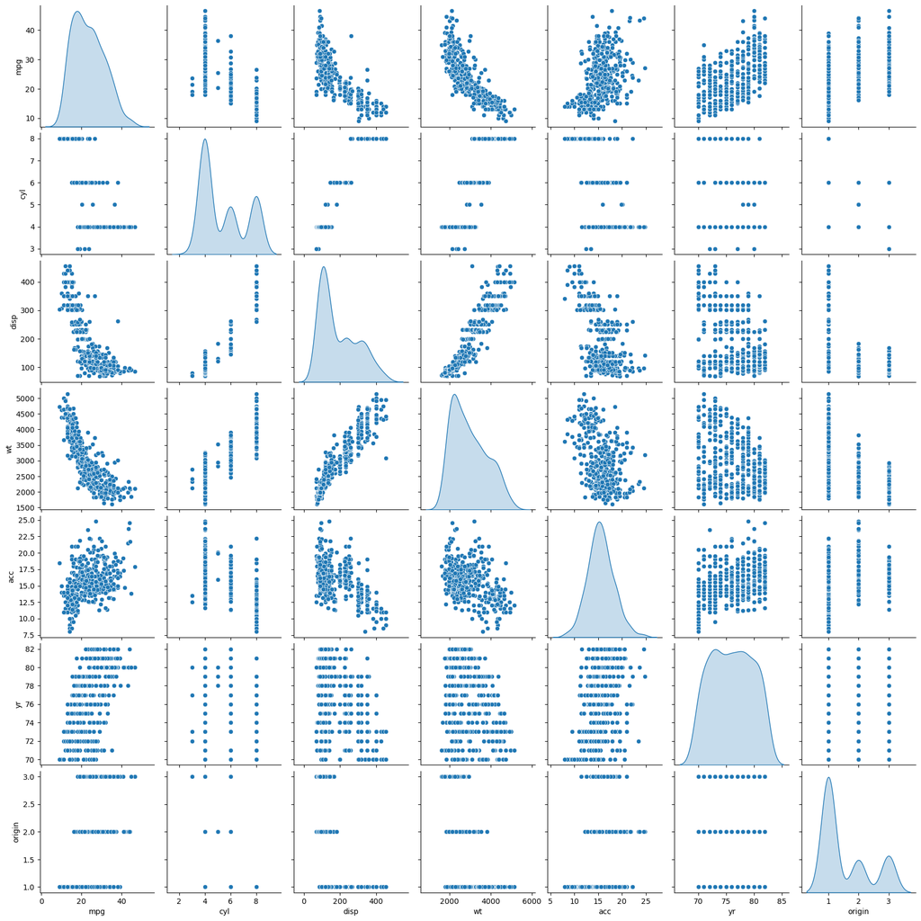

```python
import seaborn as sns
sns.pairplot(Car, diag_kind='kde')
```

**D. Visualize a scatterplot for ‘wt’ and ‘disp’. Datapoints should be distinguishable by ‘cyl’. [1 Marks]**

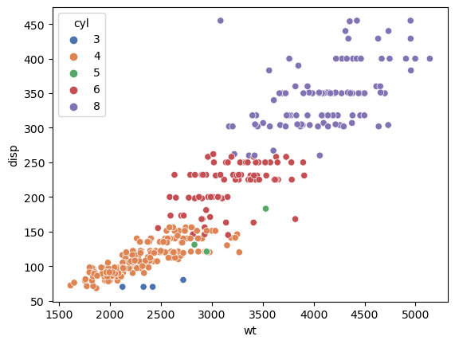

```python
import seaborn as sns
sns.scatterplot(data=Car, x="wt", y="disp", hue="cyl", palette="deep")
#sns.scatterplot(data=Car, x="wt", y="disp")
plt.show()
```

**E. Share insights for Q2.d. [1 Marks]**

*The vehicle with 3 and 5 cylinders are less in number in the dataset provided.

*Light weight range is from 1500 to 2500,mid weight range is from 2500 to 3500 and heavy weight range is from 3500 to >5000

*Also the displacement is between 50 to 100 for 3 cylinder vehicles and between 100 to 200 in 5 cylinder vehicle and these vehicles have weights ranging from low range to mid range

*The vehicles with 4 cylinders are having a displacement ranging from 50 to 150 and are more prevalent with less weights ranging from 1500 to 3250

*The vehicles with 6 cylinders are having a displacement ranging from 150 to 250 and their weights range from 2500 to 4000.

*The last category are heavy weight vehicles with 8 cylinders and their displacement is highest ranging between 250 to 450

*From plot we infer that vehicles with 6 cylinders still have many vehicles with less weight or weights in midrange with better displacement than vehicles with 3 to 5 cylinders

**F. Visualize a scatterplot for ‘wt’ and ’mpg’. Datapoints should be distinguishable by ‘cyl’. [1 Marks]**

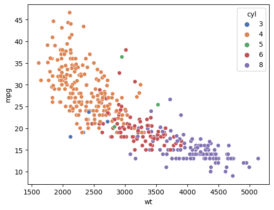

```python
sns.scatterplot(data=Car, x="wt", y="mpg", hue="cyl", palette="deep")
plt.show()
```

**H. Check for unexpected values in all the features and datapoints with such values. [2 Marks]**

```python
Car['hp'] = pd.to_numeric(Car['hp'], errors='coerce')
Car.info()
```

```
<class 'pandas.core.frame.DataFrame'>
RangeIndex: 398 entries, 0 to 397
Data columns (total 9 columns):
 #   Column    Non-Null Count  Dtype
---  ------    --------------  -----
 0   car_name  398 non-null    object
 1   mpg       398 non-null    float64
 2   cyl       398 non-null    int64
 3   disp      398 non-null    float64
 4   hp        392 non-null    float64
 5   wt        398 non-null    int64
 6   acc       398 non-null    float64
 7   yr        398 non-null    int64
 8   origin    398 non-null    int64
dtypes: float64(4), int64(4), object(1)
memory usage: 28.1+ KB
```

```python
Car.isnull().sum() * 100 / len(Car)
```

```
car_name    0.000000
mpg         0.000000
cyl         0.000000
disp        0.000000
hp          1.507538
wt          0.000000
acc         0.000000
yr          0.000000
origin      0.000000
dtype: float64
```

```python
Car["hp"].fillna("0.0", inplace = True)
Car.isnull().sum() * 100 / len(Car)
```

```
car_name    0.0
mpg         0.0
cyl         0.0
disp        0.0
hp          0.0
wt          0.0
acc         0.0
yr          0.0
origin      0.0
dtype: float64
```

```python
Car['hp'] = pd.to_numeric(Car['hp'], errors='coerce')
Car.dtypes
```

```
car_name     object
mpg         float64
cyl           int64
disp        float64
hp          float64
wt            int64
acc         float64
yr            int64
origin        int64
dtype: object
```

## 3. Clustering: [15 Marks]

**A. Apply K-Means clustering for 2 to 10 clusters. [3 Marks]**

```python
Cars = Car[Car.columns[~Car.columns.isin(['car_name'])]]
Cars.info()
```

```
<class 'pandas.core.frame.DataFrame'>
RangeIndex: 398 entries, 0 to 397
Data columns (total 8 columns):
 #   Column  Non-Null Count  Dtype
---  ------  --------------  -----
 0   mpg     398 non-null    float64
 1   cyl     398 non-null    int64
 2   disp    398 non-null    float64
 3   hp      398 non-null    float64
 4   wt      398 non-null    int64
 5   acc     398 non-null    float64
 6   yr      398 non-null    int64
 7   origin  398 non-null    int64
dtypes: float64(4), int64(4)
memory usage: 25.0 KB
```

```python
from scipy.spatial.distance import cdist
clusters=range(2,10)
meanDistortions=[]

for k in clusters:
    model=KMeans(n_clusters=k)
    model.fit(Cars)
    prediction=model.predict(Cars)
    meanDistortions.append(sum(np.min(cdist(Cars, model.cluster_centers_, 'euclidean'), axis=1)) / Cars.shape[0])
```

**B. Plot a visual and find elbow point. [2 Marks]**

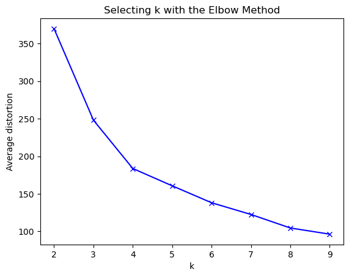

```python
plt.plot(clusters, meanDistortions, 'bx-')
plt.xlabel('k')
plt.ylabel('Average distortion')
plt.title('Selecting k with the Elbow Method')
plt.show()
```

**C. On the above visual, highlight which are the possible Elbow points. [1 Marks]**

*The elbow takes a steep descend at cluster size 3 and 4 and beyond these the graph is a gradual descend curve*  
*The optimal number of clusters from elbow is 4*

**D. Train a K-means clustering model once again on the optimal number of clusters. [3 Marks]**

```python
##Scale the data
from scipy.stats import zscore
Cars_z = Cars.apply(zscore)
#Set the value of k=3
kmeans = KMeans(n_clusters=4, n_init = 15, random_state=2345)
kmeans.fit(Cars_z)
centroids = kmeans.cluster_centers_
centroids
```

```
array([[-0.46763618,  0.32733347,  0.28263074, -0.07629208,  0.31202243,
         0.36282505,  0.020825  , -0.66086796],
       [-1.15871315,  1.49819126,  1.50068407,  1.47221226,  1.40001604,
        -1.07612225, -0.6725559 , -0.71514478],
       [ 0.21839737, -0.83346123, -0.81858344, -0.50358623, -0.77103477,
         0.27102847, -0.60475609,  0.71502297],
       [ 1.20930879, -0.80181798, -0.78011964, -0.74973992, -0.76195376,
         0.37903497,  1.15061841,  0.51010408]])
```

```python
#Clculate the centroids for the columns to profile
centroid_df = pd.DataFrame(centroids, columns = list(Cars_z))
print(centroid_df)
```

```
        mpg       cyl      disp        hp        wt       acc        yr  \
0 -0.467636  0.327333  0.282631 -0.076292  0.312022  0.362825  0.020825
1 -1.158713  1.498191  1.500684  1.472212  1.400016 -1.076122 -0.672556
2  0.218397 -0.833461 -0.818583 -0.503586 -0.771035  0.271028 -0.604756
3  1.209309 -0.801818 -0.780120 -0.749740 -0.761954  0.379035  1.150618

     origin
0 -0.660868
1 -0.715145
2  0.715023
3  0.510104
```

**E. Add a new feature in the DataFrame which will have labels based upon cluster value. [2 Marks]**

```python
## creating a new dataframe only for labels and converting it into categorical variable
df_labels = pd.DataFrame(kmeans.labels_ , columns = list(['labels']))
df_labels['labels'] = df_labels['labels'].astype('category')
# Joining the label dataframe with the data frame.
df_labeled = Cars.join(df_labels)
df_analysis = (df_labeled.groupby(['labels'] , axis=0)).head(4177)  # the groupby creates a groupeddataframe that needs
# to be converted back to dataframe.
df_analysis
```

|  | mpg | cyl | disp | hp | wt | acc | yr | origin | labels |
| --- | --- | --- | --- | --- | --- | --- | --- | --- | --- |
| 0 | 18.0 | 8 | 307.0 | 130.0 | 3504 | 12.0 | 70 | 1 | 1 |
| 1 | 15.0 | 8 | 350.0 | 165.0 | 3693 | 11.5 | 70 | 1 | 1 |
| 2 | 18.0 | 8 | 318.0 | 150.0 | 3436 | 11.0 | 70 | 1 | 1 |
| 3 | 16.0 | 8 | 304.0 | 150.0 | 3433 | 12.0 | 70 | 1 | 1 |
| 4 | 17.0 | 8 | 302.0 | 140.0 | 3449 | 10.5 | 70 | 1 | 1 |
| ... | ... | ... | ... | ... | ... | ... | ... | ... | ... |
| 393 | 27.0 | 4 | 140.0 | 86.0 | 2790 | 15.6 | 82 | 1 | 3 |
| 394 | 44.0 | 4 | 97.0 | 52.0 | 2130 | 24.6 | 82 | 2 | 3 |
| 395 | 32.0 | 4 | 135.0 | 84.0 | 2295 | 11.6 | 82 | 1 | 3 |
| 396 | 28.0 | 4 | 120.0 | 79.0 | 2625 | 18.6 | 82 | 1 | 3 |
| 397 | 31.0 | 4 | 119.0 | 82.0 | 2720 | 19.4 | 82 | 1 | 3 |

398 rows × 9 columns

```python
df_labeled['labels'].value_counts()
```

```
3    108
2    103
1     95
0     92
Name: labels, dtype: int64
```

**F. Plot a visual and color the datapoints based upon clusters. [2 Marks]**

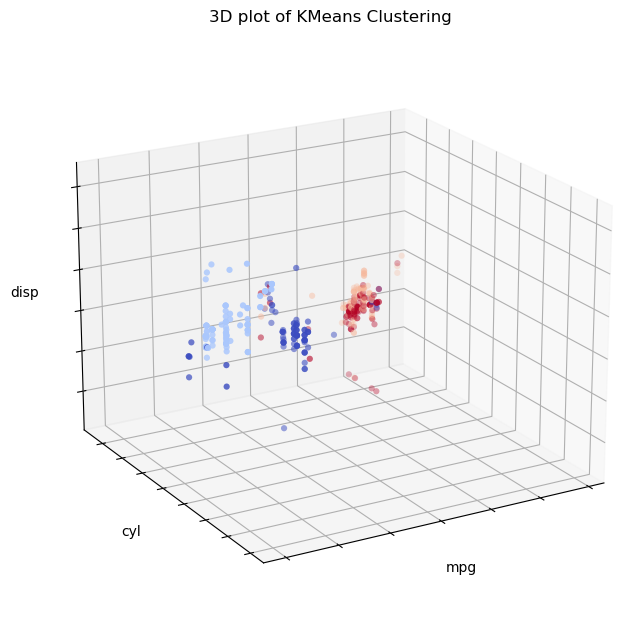

```python
from mpl_toolkits.mplot3d import Axes3D
from matplotlib import cm
## 3D plots of clusters
fig = plt.figure(figsize=(8, 6))
ax = Axes3D(fig, rect=[0, 0, .95, 1], elev=20, azim=60)
kmeans.fit(Cars_z)
labels = kmeans.labels_
ax.scatter(Cars_z.iloc[:, 1], Cars_z.iloc[:, 2], Cars_z.iloc[:, 3],c=labels.astype(np.float),cmap=cm.coolwarm,edgecolor='none')
ax.w_xaxis.set_ticklabels([])
ax.w_yaxis.set_ticklabels([])
ax.w_zaxis.set_ticklabels([])
ax.set_xlabel('mpg')
ax.set_ylabel('cyl')
ax.set_zlabel('disp')
ax.set_title('3D plot of KMeans Clustering')
plt.show()
```

**G. Pass a new DataPoint and predict which cluster it belongs to. [2 Marks]**

```python
pip install joblib
```

```python
import joblib
joblib.dump(model, 'kmeans.pkl')
model_loaded = joblib.load('kmeans.pkl')

model_loaded
```

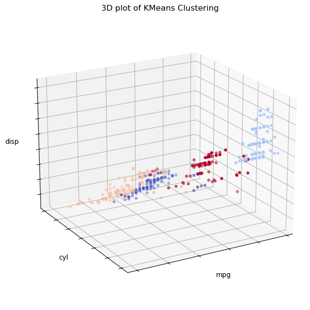

```
Before adding New point Cars : (398, 8)
New point added in Cars : (399, 9)
```

```python
Car2=pd.read_csv('D:\\Great Learning\\Unsupervised learning\\Project\\Car2.csv')
from scipy.stats import zscore
Car2_z = Car2.apply(zscore)
from mpl_toolkits.mplot3d import Axes3D
from matplotlib import cm
## 3D plots of clusters
fig = plt.figure(figsize=(8, 6))
ax = Axes3D(fig, rect=[0, 0, .95, 1], elev=20, azim=60)
kmeans.fit(Car2_z)
labels = kmeans.labels_
ax.scatter(Car2_z.iloc[:, 1], Car2_z.iloc[:, 2], Car2_z.iloc[:, 3],c=labels.astype(np.float),cmap=cm.coolwarm,edgecolor='none')
ax.w_xaxis.set_ticklabels([])
ax.w_yaxis.set_ticklabels([])
ax.w_zaxis.set_ticklabels([])
ax.set_xlabel('mpg')
ax.set_ylabel('cyl')
ax.set_zlabel('disp')
ax.set_title('3D plot of KMeans Clustering')
plt.show()
print("Before adding New point Cars :", Cars.shape)
print("New point added in Cars :", Car2.shape)
```

```python
## creating a new dataframe only for labels and converting it into categorical variable
df_labels = pd.DataFrame(kmeans.labels_ , columns = list(['labels']))
df_labels['labels'] = df_labels['labels'].astype('category')
# Joining the label dataframe with the data frame.
df_labeled = Car2.join(df_labels)
df_analysis = (df_labeled.groupby(['labels'] , axis=0)).head(4177)  # the groupby creates a groupeddataframe that needs
# to be converted back to dataframe.
df_analysis
```

|  | Unnamed: 0 | mpg | cyl | disp | hp | wt | acc | yr | origin | labels |
| --- | --- | --- | --- | --- | --- | --- | --- | --- | --- | --- |
| 0 | 0 | 18.0 | 8 | 307.0 | 130 | 3504 | 12.0 | 70 | 1 | 1 |
| 1 | 1 | 15.0 | 8 | 350.0 | 165 | 3693 | 11.5 | 70 | 1 | 1 |
| 2 | 2 | 18.0 | 8 | 318.0 | 150 | 3436 | 11.0 | 70 | 1 | 1 |
| 3 | 3 | 16.0 | 8 | 304.0 | 150 | 3433 | 12.0 | 70 | 1 | 1 |
| 4 | 4 | 17.0 | 8 | 302.0 | 140 | 3449 | 10.5 | 70 | 1 | 1 |
| ... | ... | ... | ... | ... | ... | ... | ... | ... | ... | ... |
| 394 | 394 | 44.0 | 4 | 97.0 | 52 | 2130 | 24.6 | 82 | 2 | 2 |
| 395 | 395 | 32.0 | 4 | 135.0 | 84 | 2295 | 11.6 | 82 | 1 | 2 |
| 396 | 396 | 28.0 | 4 | 120.0 | 79 | 2625 | 18.6 | 82 | 1 | 2 |
| 397 | 397 | 31.0 | 4 | 119.0 | 82 | 2720 | 19.4 | 82 | 1 | 2 |
| 398 | 398 | 10.0 | 6 | 110.0 | 81 | 2740 | 18.4 | 81 | 1 | 3 |

399 rows × 10 columns

*The last row of the above table shows the new point added and the cluster that it belongs to after KMeans clustering is done*

# Part B - 30 Marks: DOMAIN: Automobile

### 1. Data Understanding & Cleaning: [5 Marks]

```python
import numpy as np
from sklearn.linear_model import LinearRegression
import pandas as pd
import matplotlib.pyplot as plt
%matplotlib inline
import seaborn as sns
from sklearn.decomposition import PCA
```

**A. Read ‘vehicle.csv’ and save as DataFrame. [1 Marks]**

```python
vehicle1=pd.read_csv('D:\\Great Learning\\Unsupervised learning\\Project\\vehicle1.csv')
vehicle=pd.read_csv('D:\\Great Learning\\Unsupervised learning\\Project\\vehicle.csv')
vehicle1
```

|  | Unnamed: 0 | compactness | circularity | distance_circularity | radius_ratio | pr.axis_aspect_ratio | max.length_aspect_ratio | scatter_ratio | elongatedness | pr.axis_rectangularity | max.length_rectangularity | scaled_variance | scaled_variance.1 | scaled_radius_of_gyration | scaled_radius_of_gyration.1 | skewness_about | skewness_about.1 | skewness_about.2 | hollows_ratio | class |
| --- | --- | --- | --- | --- | --- | --- | --- | --- | --- | --- | --- | --- | --- | --- | --- | --- | --- | --- | --- | --- |
| 0 | 0 | 95 | 48.0 | 83.0 | 178.0 | 72.0 | 10 | 162.0 | 42.0 | 20.0 | 159 | 176.0 | 379.0 | 184.0 | 70.0 | 6.0 | 16.0 | 187.0 | 197 | van |
| 1 | 1 | 91 | 41.0 | 84.0 | 141.0 | 57.0 | 9 | 149.0 | 45.0 | 19.0 | 143 | 170.0 | 330.0 | 158.0 | 72.0 | 9.0 | 14.0 | 189.0 | 199 | van |
| 2 | 2 | 104 | 50.0 | 106.0 | 209.0 | 66.0 | 10 | 207.0 | 32.0 | 23.0 | 158 | 223.0 | 635.0 | 220.0 | 73.0 | 14.0 | 9.0 | 188.0 | 196 | car |
| 3 | 3 | 93 | 41.0 | 82.0 | 159.0 | 63.0 | 9 | 144.0 | 46.0 | 19.0 | 143 | 160.0 | 309.0 | 127.0 | 63.0 | 6.0 | 10.0 | 199.0 | 207 | van |
| 4 | 4 | 85 | 44.0 | 70.0 | 205.0 | 103.0 | 52 | 149.0 | 45.0 | 19.0 | 144 | 241.0 | 325.0 | 188.0 | 127.0 | 9.0 | 11.0 | 180.0 | 183 | bus |
| ... | ... | ... | ... | ... | ... | ... | ... | ... | ... | ... | ... | ... | ... | ... | ... | ... | ... | ... | ... | ... |
| 841 | 841 | 93 | 39.0 | 87.0 | 183.0 | 64.0 | 8 | 169.0 | 40.0 | 20.0 | 134 | 200.0 | 422.0 | 149.0 | 72.0 | 7.0 | 25.0 | 188.0 | 195 | car |
| 842 | 842 | 89 | 46.0 | 84.0 | 163.0 | 66.0 | 11 | 159.0 | 43.0 | 20.0 | 159 | 173.0 | 368.0 | 176.0 | 72.0 | 1.0 | 20.0 | 186.0 | 197 | van |
| 843 | 843 | 106 | 54.0 | 101.0 | 222.0 | 67.0 | 12 | 222.0 | 30.0 | 25.0 | 173 | 228.0 | 721.0 | 200.0 | 70.0 | 3.0 | 4.0 | 187.0 | 201 | car |
| 844 | 844 | 86 | 36.0 | 78.0 | 146.0 | 58.0 | 7 | 135.0 | 50.0 | 18.0 | 124 | 155.0 | 270.0 | 148.0 | 66.0 | 0.0 | 25.0 | 190.0 | 195 | car |
| 845 | 845 | 85 | 36.0 | 66.0 | 123.0 | 55.0 | 5 | 120.0 | 56.0 | 17.0 | 128 | 140.0 | 212.0 | 131.0 | 73.0 | 1.0 | 18.0 | 186.0 | 190 | van |

846 rows × 20 columns

**B. Check percentage of missing values and impute with correct approach. [1 Marks]**

```python
vehicle1.info()
vehicle1.isnull().sum() * 100 / len(vehicle1)
```

```
<class 'pandas.core.frame.DataFrame'>
RangeIndex: 846 entries, 0 to 845
Data columns (total 20 columns):
 #   Column                       Non-Null Count  Dtype
---  ------                       --------------  -----
 0   Unnamed: 0                   846 non-null    int64
 1   compactness                  846 non-null    int64
 2   circularity                  841 non-null    float64
 3   distance_circularity         842 non-null    float64
 4   radius_ratio                 840 non-null    float64
 5   pr.axis_aspect_ratio         844 non-null    float64
 6   max.length_aspect_ratio      846 non-null    int64
 7   scatter_ratio                845 non-null    float64
 8   elongatedness                845 non-null    float64
 9   pr.axis_rectangularity       843 non-null    float64
 10  max.length_rectangularity    846 non-null    int64
 11  scaled_variance              843 non-null    float64
 12  scaled_variance.1            844 non-null    float64
 13  scaled_radius_of_gyration    844 non-null    float64
 14  scaled_radius_of_gyration.1  842 non-null    float64
 15  skewness_about               840 non-null    float64
 16  skewness_about.1             845 non-null    float64
 17  skewness_about.2             845 non-null    float64
 18  hollows_ratio                846 non-null    int64
 19  class                        846 non-null    object
dtypes: float64(14), int64(5), object(1)
memory usage: 132.3+ KB
```

```
Unnamed: 0                     0.000000
compactness                    0.000000
circularity                    0.591017
distance_circularity           0.472813
radius_ratio                   0.709220
pr.axis_aspect_ratio           0.236407
max.length_aspect_ratio        0.000000
scatter_ratio                  0.118203
elongatedness                  0.118203
pr.axis_rectangularity         0.354610
max.length_rectangularity      0.000000
scaled_variance                0.354610
scaled_variance.1              0.236407
scaled_radius_of_gyration      0.236407
scaled_radius_of_gyration.1    0.472813
skewness_about                 0.709220
skewness_about.1               0.118203
skewness_about.2               0.118203
hollows_ratio                  0.000000
class                          0.000000
dtype: float64
```

```python
cols=['circularity','distance_circularity','radius_ratio','pr.axis_aspect_ratio','scatter_ratio','elongatedness','pr.axis_rectangularity','scaled_variance',
'scaled_variance.1','scaled_radius_of_gyration','scaled_radius_of_gyration.1','skewness_about','skewness_about.1','skewness_about.2']
vehicle[cols] = vehicle[cols].fillna(vehicle[cols].mode().iloc[0])
```

```python
#vehicle.to_csv('D:\\Great Learning\\Unsupervised learning\\Project\\vehicle.csv')
vehicle.isnull().sum() * 100 / len(vehicle)
```

```
Unnamed: 0.1                   0.0
Unnamed: 0                     0.0
compactness                    0.0
circularity                    0.0
distance_circularity           0.0
radius_ratio                   0.0
pr.axis_aspect_ratio           0.0
max.length_aspect_ratio        0.0
scatter_ratio                  0.0
elongatedness                  0.0
pr.axis_rectangularity         0.0
max.length_rectangularity      0.0
scaled_variance                0.0
scaled_variance.1              0.0
scaled_radius_of_gyration      0.0
scaled_radius_of_gyration.1    0.0
skewness_about                 0.0
skewness_about.1               0.0
skewness_about.2               0.0
hollows_ratio                  0.0
class                          0.0
dtype: float64
```

**C. Visualize a Pie-chart and print percentage of values for variable ‘class’. [2 Marks]**

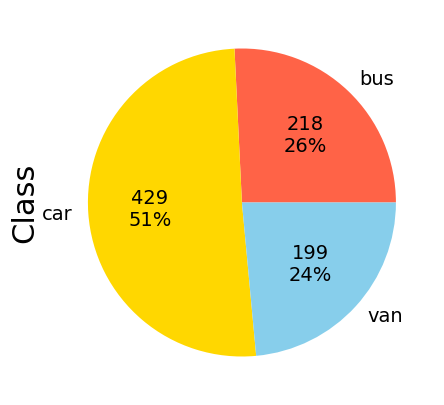

```python
def label_function(val):
    return f'{val / 100 * len(vehicle):.0f}\n{val:.0f}%'
fig, (ax1) = plt.subplots(ncols=1, figsize=(10, 5))

vehicle.groupby('class').size().plot(kind='pie', autopct=label_function, textprops={'fontsize': 14},
                                  colors=['tomato', 'gold', 'skyblue'], ax=ax1)

ax1.set_ylabel('Class', size=22)

plt.show()
```

**D. Check for duplicate rows in the data and impute with correct approach. [1 Marks]**

```python
duplicate = vehicle[vehicle.duplicated()]

print("Duplicate Rows :")
duplicate
```

```
Duplicate Rows :
```

|  | Unnamed: 0.1 | Unnamed: 0 | compactness | circularity | distance_circularity | radius_ratio | pr.axis_aspect_ratio | max.length_aspect_ratio | scatter_ratio | elongatedness | ... | max.length_rectangularity | scaled_variance | scaled_variance.1 | scaled_radius_of_gyration | scaled_radius_of_gyration.1 | skewness_about | skewness_about.1 | skewness_about.2 | hollows_ratio | class |
| --- | --- | --- | --- | --- | --- | --- | --- | --- | --- | --- | --- | --- | --- | --- | --- | --- | --- | --- | --- | --- | --- |

0 rows × 21 columns

*No duplicate rows*

### 2. Data Preparation: [2 Marks]

**A. Split data into X and Y. [Train and Test optional] [1 Marks]**

```python
X = vehicle.iloc[:,0:16].values
y = vehicle.iloc[:,17].values
from sklearn.model_selection import train_test_split
X_train, X_test, y_train, y_test = train_test_split(X,y, test_size = 0.2, random_state = 10)
```

**B. Standardize the Data. [1 Marks]**

```python
from sklearn.preprocessing import StandardScaler
X_train_sd = StandardScaler().fit_transform(X_train)
X_test_sd = StandardScaler().fit_transform(X_test)
X_sd=StandardScaler().fit_transform(X)
```

### 3. Model Building: [13 Marks]

```python
from sklearn.svm import SVC
cov_matrix = np.cov(X_train_sd.T) # the relevanat covariance matrix
print('Covariance Matrix \n%s', cov_matrix)

#generating the eigen values and the eigen vectors
e_vals, e_vecs = np.linalg.eig(cov_matrix)
print('Eigenvectors \n%s' %e_vecs)
print('\nEigenvalues \n%s' %e_vals)

#clf = SVC()
#clf.fit(X_train_sd, y_train)
#clf.fit(X_sd_pca, y_train)
```

```
Covariance Matrix
%s [[ 1.00148148  1.00148148  0.0700483   0.04535372  0.04754978  0.01348064
  -0.06613783 -0.04183405  0.05457585 -0.04666582  0.05893791  0.03073407
   0.0346754   0.05347608  0.02970606 -0.05494109]
 [ 1.00148148  1.00148148  0.0700483   0.04535372  0.04754978  0.01348064
  -0.06613783 -0.04183405  0.05457585 -0.04666582  0.05893791  0.03073407
   0.0346754   0.05347608  0.02970606 -0.05494109]
 [ 0.0700483   0.0700483   1.00148148  0.69007264  0.79112996  0.67649623
   0.07802515  0.13193425  0.81084095 -0.78284923  0.81299687  0.6899308
   0.75076172  0.80981931  0.59004956 -0.25735782]
 [ 0.04535372  0.04535372  0.69007264  1.00148148  0.78562825  0.63134509
   0.16700106  0.23087997  0.84541859 -0.81674371  0.83771736  0.96183417
   0.79248695  0.83206871  0.92250774  0.03957228]
 [ 0.04754978  0.04754978  0.79112996  0.78562825  1.00148148  0.76181749
   0.14991442  0.2411094   0.90298002 -0.90795478  0.89071352  0.77497364
   0.85337741  0.88305386  0.69994253 -0.22914879]
 [ 0.01348064  0.01348064  0.67649623  0.63134509  0.76181749  1.00148148
   0.66858725  0.47111027  0.73108827 -0.78350411  0.70639322  0.58784411
   0.79768378  0.71324382  0.54451426 -0.14192939]
 [-0.06613783 -0.06613783  0.07802515  0.16700106  0.14991442  0.66858725
   1.00148148  0.69343522  0.09778856 -0.1741959   0.07470038  0.14546154
   0.2883753   0.08260602  0.13213856  0.21555318]
 [-0.04183405 -0.04183405  0.13193425  0.23087997  0.2411094   0.47111027
   0.69343522  1.00148148  0.14755774 -0.16084864  0.14152669  0.28242678
   0.33108865  0.12612543  0.17588755  0.35283963]
 [ 0.05457585  0.05457585  0.81084095  0.84541859  0.90298002  0.73108827
   0.09778856  0.14755774  1.00148148 -0.97166762  0.99008126  0.81407349
   0.94126695  0.99298663  0.80012186 -0.03957373]
 [-0.04666582 -0.04666582 -0.78284923 -0.81674371 -0.90795478 -0.78350411
  -0.1741959  -0.16084864 -0.97166762  1.00148148 -0.94745981 -0.77632792
  -0.92808672 -0.95183416 -0.7643888   0.10895829]
 [ 0.05893791  0.05893791  0.81299687  0.83771736  0.89071352  0.70639322
   0.07470038  0.14152669  0.99008126 -0.94745981  1.00148148  0.81333068
   0.92601651  0.98730742  0.7943346  -0.03033971]
 [ 0.03073407  0.03073407  0.6899308   0.96183417  0.77497364  0.58784411
   0.14546154  0.28242678  0.81407349 -0.77632792  0.81333068  1.00148148
   0.74996423  0.79969052  0.86972518  0.03249405]
 [ 0.0346754   0.0346754   0.75076172  0.79248695  0.85337741  0.79768378
   0.2883753   0.33108865  0.94126695 -0.92808672  0.92601651  0.74996423
   1.00148148  0.93639523  0.77846623  0.12905023]
```

[output cut: 65 more lines]

```
  -1.07891524e-02  4.12621382e-01 -6.35709875e-01 -2.48117429e-01]
 [-2.78713662e-01  7.69815518e-03  2.19918106e-02  3.36536857e-01
   3.05400571e-01 -2.95017816e-01 -1.64158757e-02  7.06211063e-01
  -1.77856234e-01 -5.31746763e-16  1.61640316e-01  1.90233170e-01
  -1.54784446e-01 -1.19128303e-02 -2.34826121e-02  1.03002456e-01]
 [ 1.00154709e-02  2.83716307e-01 -2.46808312e-01  7.09502533e-01
  -3.84806126e-01  1.78681152e-02 -1.94780914e-01 -8.35887624e-02
   3.27672366e-01  1.66280611e-15 -3.63865641e-02  5.50033935e-02
   1.24634266e-01  3.26634896e-02 -5.45372229e-02  1.74589240e-01]]

Eigenvalues
[9.29021740e+00 2.16777826e+00 1.84249651e+00 1.21603906e+00
 5.53503468e-01 3.86952951e-01 2.44167817e-01 9.99716456e-02
 7.84448252e-02 3.99517559e-16 4.63275419e-02 3.59333583e-02
 2.62273847e-02 3.99144367e-03 1.24274705e-02 1.92245655e-02]
```

```python
tot = sum(e_vals)
var_exp = [( i /tot ) * 100 for i in sorted(e_vals, reverse=True)]
cum_var_exp = np.cumsum(var_exp)
print("Cumulative Variance Explained", cum_var_exp)
```

```
Cumulative Variance Explained [ 57.97796549  71.50653729  83.00510555  90.59410671  94.04838593
  96.46326428  97.98705567  98.61095416  99.10050905  99.38962786
  99.61387913  99.7775578   99.89753359  99.97509038 100.
 100.        ]
```

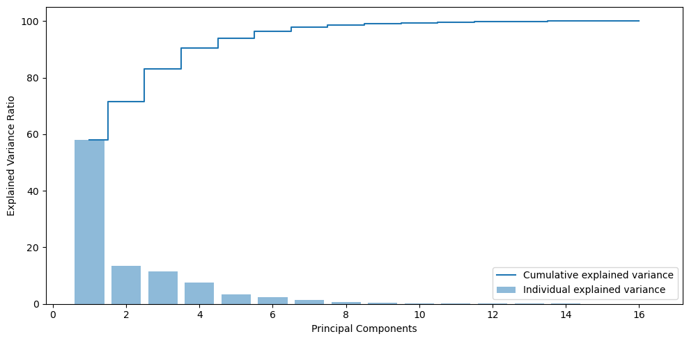

```python
plt.figure(figsize=(10 , 5))
plt.bar(range(1, e_vals.size + 1), var_exp, alpha = 0.5, align = 'center', label = 'Individual explained variance')
plt.step(range(1, e_vals.size + 1), cum_var_exp, where='mid', label = 'Cumulative explained variance')
plt.ylabel('Explained Variance Ratio')
plt.xlabel('Principal Components')
plt.legend(loc = 'best')
plt.tight_layout()
plt.show()
```

```python
eigen_pairs = [(np.abs(e_vals[i]), e_vecs[:,i]) for i in range(len(e_vals))]
eigen_pairs.sort(reverse=True)
eigen_pairs[:17]
```

```
[(9.29021740421507,
  array([-0.0188869 , -0.0188869 , -0.27313981, -0.29757781, -0.30281475,
         -0.26551234, -0.0793806 , -0.09275066, -0.31949799,  0.31469192,
         -0.31623458, -0.28883813, -0.31124265, -0.31596798, -0.27871366,
          0.01001547])),
 (2.167778259270756,
  array([-0.49028064, -0.49028064, -0.10233054, -0.00453357, -0.04705765,
          0.17772113,  0.44268598,  0.42286124, -0.0639183 ,  0.04321264,
         -0.07223628,  0.00590747,  0.05935894, -0.06994589,  0.00769816,
          0.28371631])),
 (1.842496508573721,
  array([-0.50855658, -0.50855658,  0.08405308,  0.01826099,  0.05469525,
         -0.17513667, -0.42192428, -0.42175786,  0.0749141 , -0.05716794,
          0.07925814,  0.01963274, -0.04491214,  0.08255379,  0.02199181,
         -0.24680831])),
 (1.2160390600588216,
  array([ 0.02028062,  0.02028062, -0.20895051,  0.19483416, -0.16883528,
         -0.37949102, -0.27821829, -0.04710507,  0.03173498,  0.0658667 ,
          0.04951936,  0.19093371,  0.04911017,  0.045799  ,  0.33653686,
          0.70950253])),
 (0.5535034681949829,
  array([ 0.00080137,  0.00080137, -0.02973434,  0.43709323,  0.01239464,
         -0.08634055,  0.04034659,  0.16464554, -0.20015086,  0.18538307,
         -0.19711937,  0.51017548, -0.3224561 , -0.22985703,  0.30540057,
         -0.38480613])),
 (0.38695295125931534,
  array([-0.01166833, -0.01166833,  0.36231891, -0.12746988,  0.19754175,
         -0.26767571, -0.45042947,  0.65634812,  0.00691476,  0.10775739,
          0.05135   ,  0.07872829,  0.00123321,  0.00089853, -0.29501782,
          0.01786812])),
 (0.24416781686798833,
  array([ 0.0054291 ,  0.0054291 , -0.81960933, -0.03955282,  0.38107992,
         -0.05322918, -0.16710591,  0.22604405,  0.09306682, -0.20808955,
          0.04951423, -0.04254351,  0.06211271,  0.03535869, -0.01641588,
         -0.19478091])),
 (0.0999716455658467,
  array([-0.0019968 , -0.0019968 ,  0.15753254, -0.14814566,  0.21807837,
          0.0213227 , -0.13101994,  0.12074265, -0.14971418,  0.07641076,
         -0.19429425, -0.49679393,  0.17883167, -0.1515296 ,  0.70621106,
         -0.08358876])),
```

[output cut: 25 more lines]

```
 (0.012427470523735485,
  array([-0.00190257, -0.00190257,  0.0018121 ,  0.07640754, -0.03231926,
         -0.12658148,  0.0730069 , -0.02807434, -0.16882889, -0.03086421,
          0.70070734, -0.05417725,  0.19982804, -0.63570988, -0.02348261,
         -0.05453722])),
 (0.00399144367061758,
  array([ 2.29154626e-04,  2.29154626e-04, -2.73328977e-03,  2.12016094e-02,
          1.54020509e-02,  5.71428710e-02, -5.45324742e-02,  1.17737685e-02,
         -8.55618293e-01, -2.32704533e-01,  1.84749931e-01,  9.35021898e-03,
         -3.17603812e-02,  4.12621382e-01, -1.19128303e-02,  3.26634896e-02])),
 (3.995175585249916e-16,
  array([ 7.07106781e-01, -7.07106781e-01, -7.91483757e-16,  2.36407789e-15,
          1.78531775e-15,  4.92347426e-15, -2.98506751e-15, -5.07859001e-17,
         -3.17291847e-14, -4.19926617e-15,  1.08897190e-14, -1.05455831e-15,
         -1.20014988e-15,  1.31508959e-14, -5.31746763e-16,  1.66280611e-15]))]
```

```python
# generating dimensionally reduced datasets
w = np.hstack((eigen_pairs[0][1].reshape(16,1),
                      eigen_pairs[1][1].reshape(16,1)))
print('Matrix W:\n', w)
X_sd_pca = X_train_sd.dot(w)
X_test_sd_pca = X_test_sd.dot(w)
```

```
Matrix W:
 [[-0.0188869  -0.49028064]
 [-0.0188869  -0.49028064]
 [-0.27313981 -0.10233054]
 [-0.29757781 -0.00453357]
 [-0.30281475 -0.04705765]
 [-0.26551234  0.17772113]
 [-0.0793806   0.44268598]
 [-0.09275066  0.42286124]
 [-0.31949799 -0.0639183 ]
 [ 0.31469192  0.04321264]
 [-0.31623458 -0.07223628]
 [-0.28883813  0.00590747]
 [-0.31124265  0.05935894]
 [-0.31596798 -0.06994589]
 [-0.27871366  0.00769816]
 [ 0.01001547  0.28371631]]
```

```python
X_train_sd.shape, w.shape, X_sd_pca.shape, X_test_sd_pca.shape
```

```
((676, 16), (16, 2), (676, 2), (170, 2))
```

**B. Print Classification metrics for train data. [1 Marks]**

```python
from sklearn.svm import SVC

clf = SVC()
clf.fit(X_train_sd, y_train)
print ('Before PCA score', clf.score(X_test_sd, y_test))

clf.fit(X_sd_pca, y_train)
print ('After PCA score', clf.score(X_test_sd_pca, y_test))
```

```
Before PCA score 0.052941176470588235
After PCA score 0.058823529411764705
```

**C. Apply PCA on the data with 10 components. [3 Marks]**

```python
from scipy import stats
XScaled=stats.zscore(X)
```

```python
pca10 = PCA(n_components=10)
out=pca10.fit(XScaled)
print(pca10.components_)
print(pca10.explained_variance_ratio_)
Xpca10 = pca10.transform(XScaled)
```

```
[[ 0.0195427   0.0195427   0.27324332  0.29727192  0.30319851  0.26555085
   0.07903543  0.09730467  0.31955479 -0.31500009  0.31630802  0.28657831
   0.31197148  0.31608644  0.27782904 -0.00991141]
 [-0.59198568 -0.59198568 -0.08622716  0.00122167 -0.03391072  0.1282054
   0.34087071  0.31740116 -0.04407947  0.02899061 -0.04766433  0.00937659
   0.04245263 -0.04775605  0.01572695  0.21834133]
 [ 0.38224116  0.38224116 -0.08937118 -0.02909754 -0.04942246  0.2279442
   0.53649189  0.51485969 -0.09015162  0.05970575 -0.09995674 -0.02590633
   0.03944522 -0.10120176 -0.04043479  0.23634099]
 [ 0.05186991  0.05186991 -0.21213388  0.19542105 -0.16647923 -0.36252581
  -0.24891721  0.00846623  0.02366178  0.07108369  0.04231339  0.19665361
   0.04519589  0.03558472  0.32548514  0.73139028]
 [ 0.00693229  0.00693229  0.03488726 -0.40510224 -0.05820593  0.12806203
   0.04722854 -0.26610579  0.18642234 -0.17536663  0.17919274 -0.50999719
   0.31364658  0.22102553 -0.26115839  0.41061444]
 [-0.01467099 -0.01467099  0.31221274 -0.19290177  0.19190927 -0.23836951
  -0.46481485  0.64752208  0.04384595  0.05783982  0.08208281 -0.00667389
   0.04886637  0.038874   -0.34376361  0.04209739]
 [ 0.00804853  0.00804853 -0.83912577 -0.05934915  0.36209996 -0.02472372
  -0.14457673  0.16790999  0.10313153 -0.22183043  0.05781119 -0.0844153
   0.09022774  0.04619988 -0.01056799 -0.17519172]
 [ 0.00253113  0.00253113 -0.15540635  0.1330139  -0.16944156 -0.03256905
   0.14497704 -0.14139894  0.13767363 -0.08845642  0.17834624  0.51673517
  -0.16792322  0.12744088 -0.71336448  0.09181896]
 [-0.00241731 -0.00241731 -0.12257153  0.00409313 -0.80877564  0.02266005
  -0.11840258  0.27188307  0.14358892 -0.1030072   0.16699157 -0.07754947
   0.11844631  0.21376106  0.13644989 -0.31449393]
 [-0.00207698 -0.00207698  0.08575963  0.12655351 -0.12684816 -0.00179035
  -0.13323116 -0.00634629 -0.10503628 -0.66906293 -0.48736405  0.07006999
   0.30653585 -0.35854371 -0.12888368  0.04996223]]
[0.5813259  0.13040552 0.11193    0.08010191 0.03563315 0.02558817
 0.01536337 0.00626622 0.00474737 0.00281445]
```

**D. Visualize Cumulative Variance Explained with Number of Components. [2 Marks]**

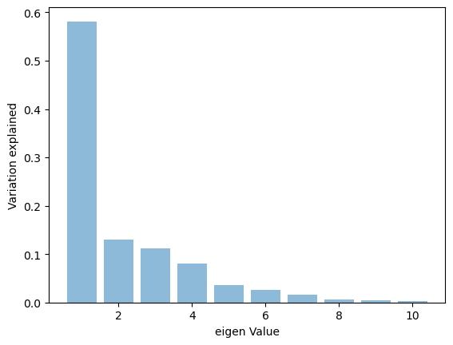

```python
plt.bar(list(range(1,11)),pca10.explained_variance_ratio_,alpha=0.5, align='center')
plt.ylabel('Variation explained')
plt.xlabel('eigen Value')
plt.show()
```

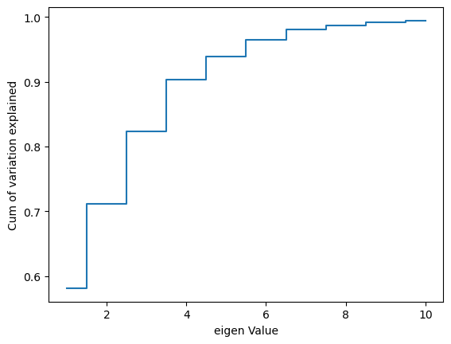

```python
plt.step(list(range(1,11)),np.cumsum(pca10.explained_variance_ratio_), where='mid')
plt.ylabel('Cum of variation explained')
plt.xlabel('eigen Value')
plt.show()
```

**E. Draw a horizontal line on the above plot to highlight the threshold of 90%. [1 Marks]**

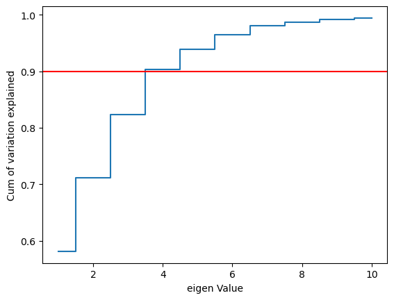

```python
plt.step(list(range(1,11)),np.cumsum(pca10.explained_variance_ratio_), where='mid')
plt.ylabel('Cum of variation explained')
plt.xlabel('eigen Value')
plt.axhline(y = 0.9, color = 'r', linestyle = '-')

# rendering the plot
plt.show()
```

**F. Apply PCA on the data. This time Select Minimum Components with 90% or above variance explained. [2 Marks]**

```python
pca5 = PCA(n_components=5)
pca5.fit(XScaled)
print(pca5.components_)
print(pca5.explained_variance_ratio_)
Xpca5 = pca5.transform(XScaled)
Xpca5
```

```
[[ 0.0195427   0.0195427   0.27324332  0.29727192  0.30319851  0.26555085
   0.07903543  0.09730467  0.31955479 -0.31500009  0.31630802  0.28657831
   0.31197148  0.31608644  0.27782904 -0.00991141]
 [-0.59198568 -0.59198568 -0.08622716  0.00122167 -0.03391072  0.1282054
   0.34087071  0.31740116 -0.04407947  0.02899061 -0.04766433  0.00937659
   0.04245263 -0.04775605  0.01572695  0.21834133]
 [ 0.38224116  0.38224116 -0.08937118 -0.02909754 -0.04942246  0.2279442
   0.53649189  0.51485969 -0.09015162  0.05970575 -0.09995674 -0.02590633
   0.03944522 -0.10120176 -0.04043479  0.23634099]
 [ 0.05186991  0.05186991 -0.21213388  0.19542105 -0.16647923 -0.36252581
  -0.24891721  0.00846623  0.02366178  0.07108369  0.04231339  0.19665361
   0.04519589  0.03558472  0.32548514  0.73139028]
 [ 0.00693229  0.00693229  0.03488726 -0.40510224 -0.05820593  0.12806203
   0.04722854 -0.26610579  0.18642234 -0.17536663  0.17919274 -0.50999719
   0.31364658  0.22102553 -0.26115839  0.41061444]]
[0.5813259  0.13040552 0.11193    0.08010191 0.03563315]
```

```
array([[ 0.240193  ,  2.57544196, -0.47211393, -0.57477413, -1.11868318],
       [-1.73440927,  1.83672418, -1.53928615, -0.1298765 , -0.3002255 ],
       [ 3.67729997,  2.22828545, -1.19278266, -0.38109721,  0.17214842],
       ...,
       [ 4.93437902, -1.79557645,  1.52213105, -0.30487673, -0.18387549],
       [-3.28394056, -2.40259598,  1.06140418, -0.78845876,  0.1526308 ],
       [-4.6397434 , -2.47200288,  0.90336015,  0.26895359,  0.07256443]])
```

```
         PC0       PC1       PC2       PC3       PC4
0   0.019543 -0.591986  0.382241  0.051870  0.006932
1   0.019543 -0.591986  0.382241  0.051870  0.006932
2   0.273243 -0.086227 -0.089371 -0.212134  0.034887
3   0.297272  0.001222 -0.029098  0.195421 -0.405102
4   0.303199 -0.033911 -0.049422 -0.166479 -0.058206
5   0.265551  0.128205  0.227944 -0.362526  0.128062
6   0.079035  0.340871  0.536492 -0.248917  0.047229
7   0.097305  0.317401  0.514860  0.008466 -0.266106
8   0.319555 -0.044079 -0.090152  0.023662  0.186422
9  -0.315000  0.028991  0.059706  0.071084 -0.175367
10  0.316308 -0.047664 -0.099957  0.042313  0.179193
11  0.286578  0.009377 -0.025906  0.196654 -0.509997
12  0.311971  0.042453  0.039445  0.045196  0.313647
13  0.316086 -0.047756 -0.101202  0.035585  0.221026
14  0.277829  0.015727 -0.040435  0.325485 -0.261158
15 -0.009911  0.218341  0.236341  0.731390  0.410614
```

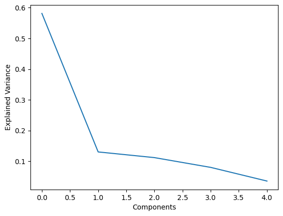

|  | 0 | 1 | 2 | 3 | 4 | 5 | 6 | 7 | 8 | 9 | 10 | 11 | 12 | 13 | 14 | 15 |
| --- | --- | --- | --- | --- | --- | --- | --- | --- | --- | --- | --- | --- | --- | --- | --- | --- |
| 0 | 0.019543 | 0.019543 | 0.273243 | 0.297272 | 0.303199 | 0.265551 | 0.079035 | 0.097305 | 0.319555 | -0.315000 | 0.316308 | 0.286578 | 0.311971 | 0.316086 | 0.277829 | -0.009911 |
| 1 | -0.591986 | -0.591986 | -0.086227 | 0.001222 | -0.033911 | 0.128205 | 0.340871 | 0.317401 | -0.044079 | 0.028991 | -0.047664 | 0.009377 | 0.042453 | -0.047756 | 0.015727 | 0.218341 |
| 2 | 0.382241 | 0.382241 | -0.089371 | -0.029098 | -0.049422 | 0.227944 | 0.536492 | 0.514860 | -0.090152 | 0.059706 | -0.099957 | -0.025906 | 0.039445 | -0.101202 | -0.040435 | 0.236341 |
| 3 | 0.051870 | 0.051870 | -0.212134 | 0.195421 | -0.166479 | -0.362526 | -0.248917 | 0.008466 | 0.023662 | 0.071084 | 0.042313 | 0.196654 | 0.045196 | 0.035585 | 0.325485 | 0.731390 |
| 4 | 0.006932 | 0.006932 | 0.034887 | -0.405102 | -0.058206 | 0.128062 | 0.047229 | -0.266106 | 0.186422 | -0.175367 | 0.179193 | -0.509997 | 0.313647 | 0.221026 | -0.261158 | 0.410614 |

```python
df = pd.DataFrame(data=pca5.components_)
loadings = pd.DataFrame(pca5.components_.T,columns=['PC%s' % _ for _ in range(len(df))],
index=df.columns)
print(loadings)

plt.plot(pca5.explained_variance_ratio_)
plt.ylabel('Explained Variance')
plt.xlabel('Components')
plt.show()
df
```

```python
from sklearn.svm import SVC

clf = SVC()
clf.fit(X_train_sd, y_train)
print ('Before PCA score', clf.score(X_train_sd, y_train))
pca5 = PCA(n_components=5)
pca5.fit(X_train_sd)
X5 = pca5.transform(X_train_sd)
clf.fit(X5, y_train)
print ('After PCA score', clf.score(X5, y_train))
```

```
Before PCA score 0.14053254437869822
After PCA score 0.12721893491124261
```

### 5. Data Understanding & Cleaning: [5 Marks]

**A. Explain pre-requisite/assumptions of PCA. [2 Marks]**

*PCA does not require statistical assumptions. However, it is sensitive to the scale of the data. As a result, the data must be standardized (standard deviation = 1 and mean =0). This means that column means in the n*p matrix will be 0. The PCA of the data needs to be based on the correlation matrix, not on the covariance matrix. Note that the principal components predict the observed covariance matrix.*

**B. Explain advantages and limitations of PCA. [3 Marks]**

**Advantages of Principal Component Analysis**